# STA101 - HW 2

Wangqian Miao

### Problem 1

**(a)**

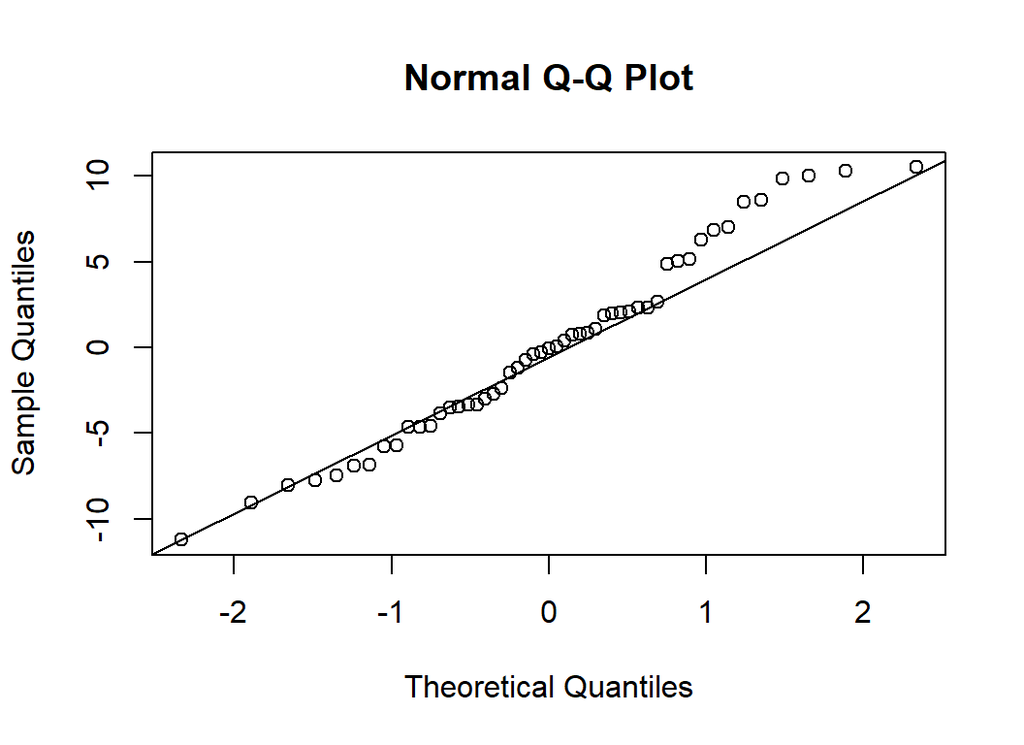

```
##
##  Shapiro-Wilk normality test
##
## data:  ei
## W = 0.97436, p-value = 0.3324
```

From the QQplot, we know that most points are close to the line, but there exits some outliers.

Test: $H_0$: The errors are normally distributed vs. $H_A$: The errors are not normally distributed.

The p-value for our test is :0.3323856

Since our p-value is relatively large, we fail to reject the null, and support that our data is normally distributed at any reasonable significance level (1%, 5%, 10%).

**(b)**

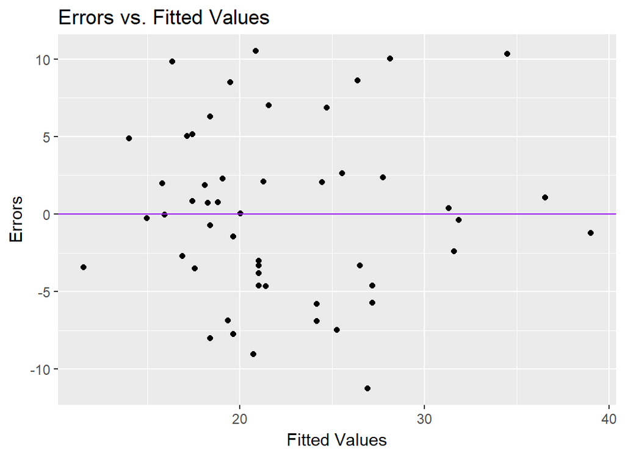

```
##
##  Fligner-Killeen test of homogeneity of variances
##
## data:  pov$ei and pov$Group
## Fligner-Killeen:med chi-squared = 1.1001, df = 1, p-value = 0.2942
```

From the plot, It shows that the variance is nearly a constant.

FKTest:I can find the p-value is: 0.2942374. This is still larger than any typical alpha, so I fail to reject $H_0$ and support that the variance is contant.

**(c)**

```
## 9
## 9
```

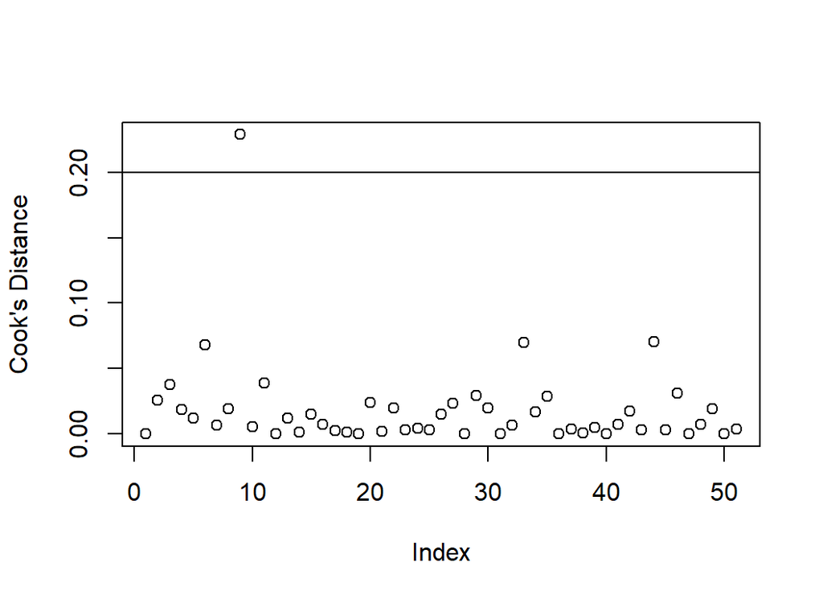

```
## integer(0)
```

I use the method of Cook Distance to remove the outliers. The cutoff value is 0.2.

**(d)**

With outliers, the $\beta s$ are

```
## (Intercept)      PovPct
##    4.267293    1.373345
```

Without outliers, the $\beta s$ are

```
## (Intercept)      PovPct
##    5.511028    1.261281
```

The absolute difference of $\beta_2$ is 0.1120647.

### Problem 2

**(a)**

```
##                  5 %     95 %
## (Intercept) 1.269982 9.752074
## PovPct      0.948736 1.573825
```

Thus the CI for $\beta_1$ is (0.948736,1.5738254)

**(b)**

We are 90% confident that when PovPct increases 1 percent, Brth15to17 rate will increase by between 0.948736 and 1.573825 on average., holding other variables are constant.

**(c)**

It shows that there exits a significant linear relationship. Because the Ci does not contain 0.

**(d)**

```
##             Estimate Std. Error  t value     Pr(>|t|)
## (Intercept) 5.511028  2.5286102 2.179469 3.423502e-02
## PovPct      1.261281  0.1863464 6.768473 1.665617e-08
```

test statistic: $t_{s}=\frac{\hat{\beta_{1}}-0}{SE\{\hat{\beta_{1}}\}}$  
`  
$H_{0}$:$\beta_{1}=0$.  
$H_{A}$:$\beta_{1}\neq 0$.  
p-value is small and we will reject $H_{0}$. So, there exists significant linear relationship between $X_{1}$ and $Y$.

**(e)** If there was no linear relationship between PocPCt and Brth15to17, we would observe our data or more extreme 1.67e-6% of the time.

### Problem 3

**(a)**

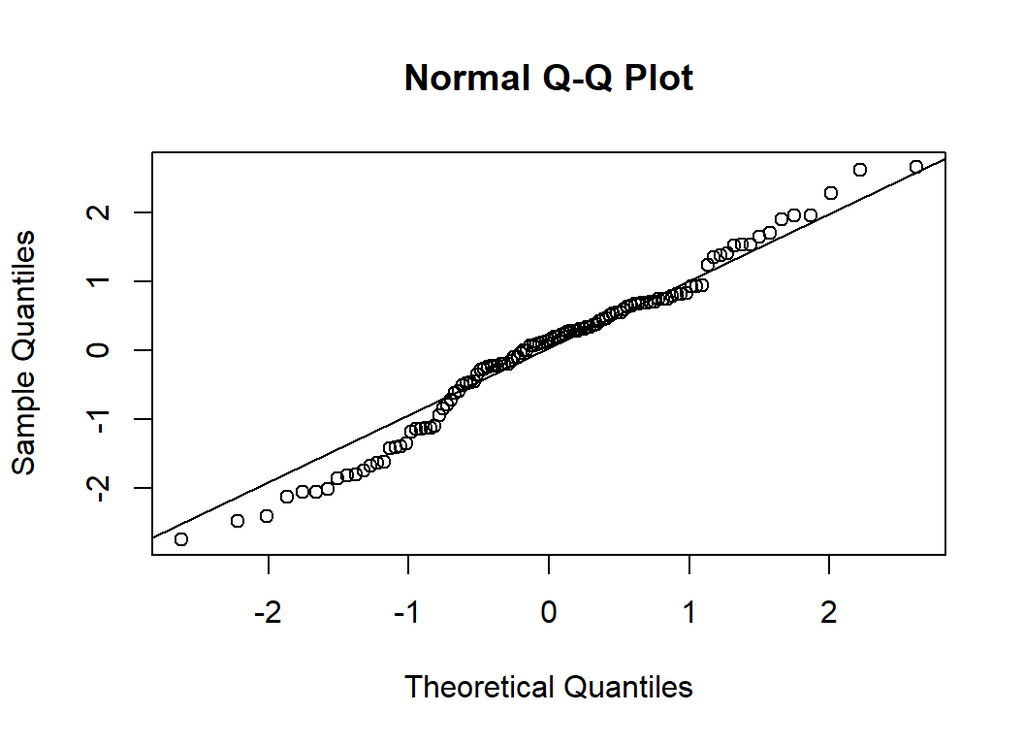

```
##
##  Shapiro-Wilk normality test
##
## data:  ei
## W = 0.97985, p-value = 0.086
```

From the QQplot, we know that most points are close to the line which suggets the $e_i$ is normal, but there exits some outliers.

Test $H_0$: The errors are normally distributed vs. $H_A$: The errors are not normally distributed.

The p-value for our test was : 0.0860007

**(b)**

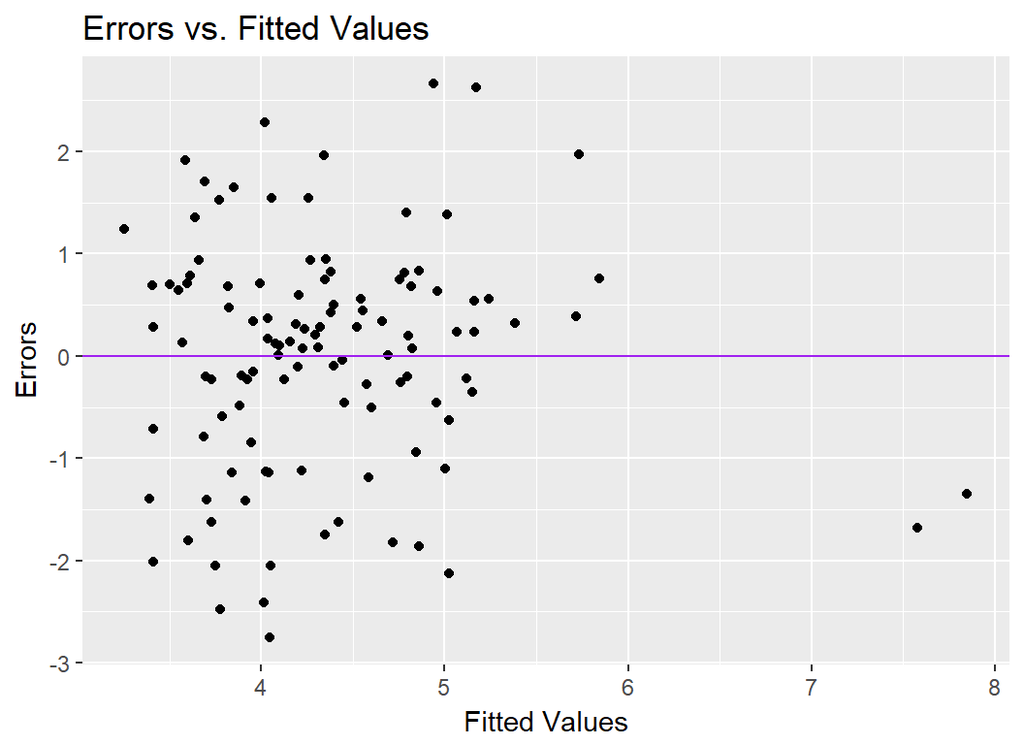

```
##
##  Fligner-Killeen test of homogeneity of variances
##
## data:  hos$ei and hos$Group
## Fligner-Killeen:med chi-squared = 3.3832, df = 1, p-value =
## 0.06587
```

From the plot, It shows that the variance is nearly a constant, but there exits some outliers.

FKTest: I can find the p-value is: 0.0658658.

**(c)**

```
##  47 112
##  47 112
```

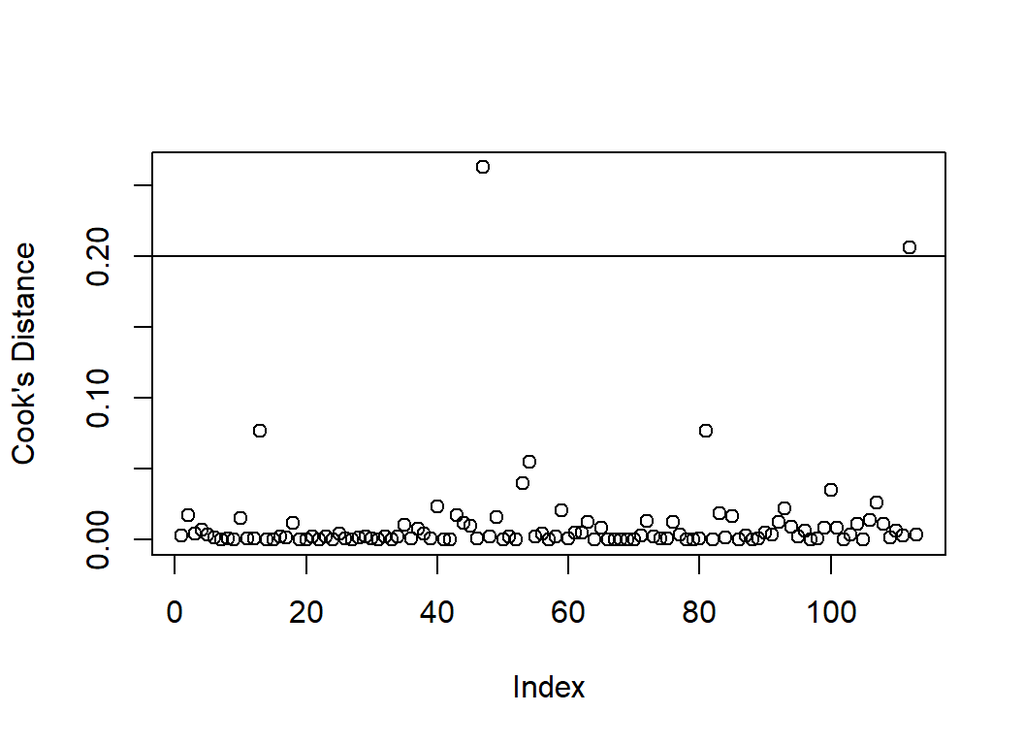

```
## integer(0)
```

I use the method of Cook Distance to remove the outliers. The cutoff value is 0.2.

**(d)**

With outliers, the $\beta s$ are

```
##  (Intercept) MedSchoolYes         Stay
##    0.8628173    0.3055990    0.3571684
```

Without outliers, the $\beta s$ are

```
##  (Intercept) MedSchoolYes         Stay
##   -0.2429811    0.2452878    0.4775507
```

```
##                     5 %      95 %
## (Intercept)  -1.4273379 0.9413756
## MedSchoolYes -0.2798846 0.7704603
## Stay          0.3519035 0.6031979
```

The CI for $\beta_1$ is (-0.2798846,0.7704603)  
The CI for $\beta_2$ is (0.3519035,0.6031979)

**(b)**

We are 90% confident in that when the Stay of days in hospital increases one day, the InfctRsk would increase between 0.3519035 and 0.6031979 percent on average, holding other variables onstant.

**(c)**

There exists a significant linear relationship between Stay and InfctRsk because the CI for $\beta_2$ does not contain 0.

**(d)**

```
##                Estimate Std. Error    t value     Pr(>|t|)
## (Intercept)  -0.2429811 0.71386132 -0.3403758 7.342347e-01
## MedSchoolYes  0.2452878 0.31654340  0.7748948 4.400951e-01
## Stay          0.4775507 0.07573283  6.3057294 6.420757e-09
```

**(e)** If there was no linear relationship between Stay and InfctRsk, we would observe our data or more extreme 6.42e-7% of the time.

If there was no linear relationship between Medschool and InfctRsk, we would observe our data or more extreme 44% of the time.

### Problem 5

**(a)**

```
##       (Intercept)      MedSchoolYes              Stay MedSchoolYes:Stay
##        -0.1030970        -1.7873098         0.4625154         0.1943226
```

$\hat{y}=-0.103097 -1.7873098X_1 +0.4625154X_2 + 0.1943226X_1X_2$

**(b)**

```
##                          5 %      95 %
## (Intercept)       -1.3380309 1.1318370
## MedSchoolYes      -6.7468561 3.1722365
## Stay               0.3313715 0.5936592
## MedSchoolYes:Stay -0.2771459 0.6657912
```

The CI for $\beta_1$ is (-6.7468561,3.1722365)

The CI for $\beta_2$ is (0.3313715,0.5936592)

The CI for $\beta_3$ is (-0.2771459,0.6657912)

**(c)**

$X_2$ should be retained. Because its CI does not contain 0.

**(d)**

When $X_{1}$ changes by 1 unit, we can expect the largiest change in $Y$.

### Problem 6

**(a)**

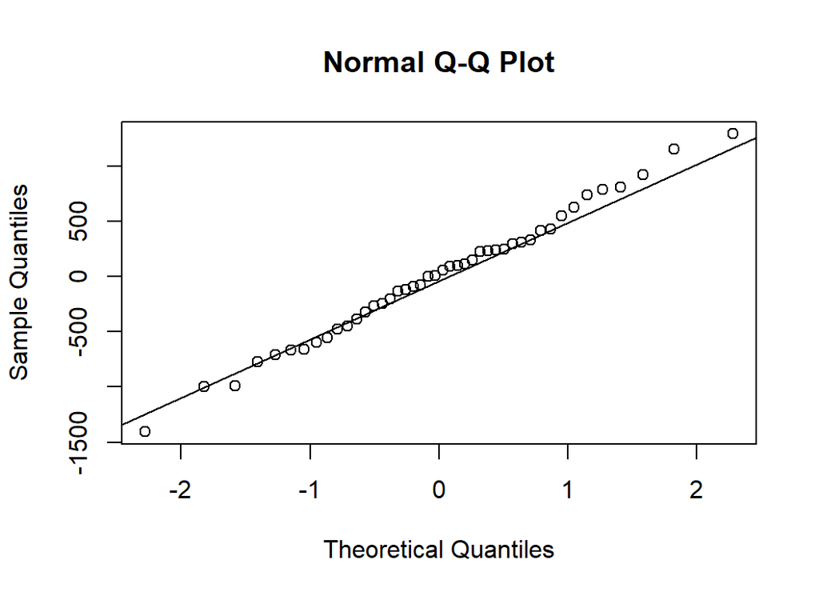

```
##
##  Shapiro-Wilk normality test
##
## data:  ei
## W = 0.99395, p-value = 0.998
```

From the QQplot, we know that most points are close to the line which means that $e_i$ are normally distributed, but there exits some outliers.

Test: $H_0$: The errors are normally distributed vs. $H_A$: The errors are not normally distributed.

The p-value for our test was :0.9979569

Since our p-value was relatively large, we fail to reject the null, and support that our data is normally distributed at any reasonable significance level (1%, 5%, 10%).

**(b)**

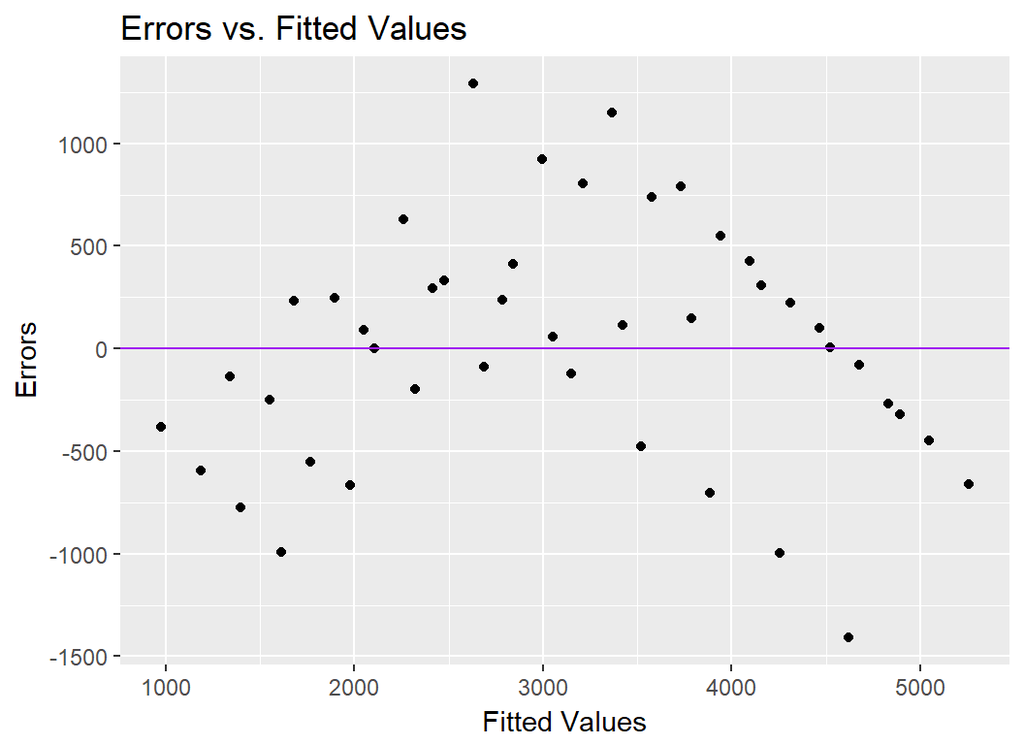

```
##
##  Fligner-Killeen test of homogeneity of variances
##
## data:  fish$ei and fish$Group
## Fligner-Killeen:med chi-squared = 2.5133, df = 1, p-value = 0.1129
```

From the plot, It shows that the variance is not a constant.

FKTest: I can find the p-value is: 0.1128873. p-value is large and we fail to reject $H_0$. So, the lower error variance is equal to the upper error variance, the variance is a constant.

**(c)**

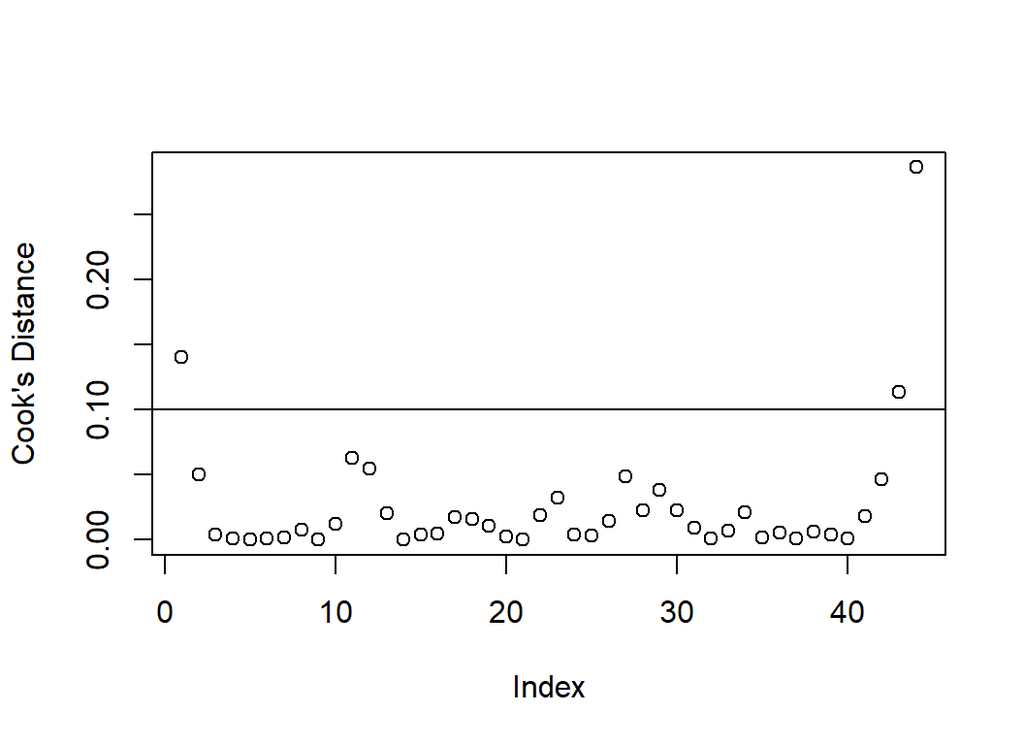

```
## integer(0)
```

I use the method of cook distance to remove the outliers, the cutoff is 0.1.

**(d)**

With outliers, the $\beta s$ are

```
## (Intercept)         Age        Temp
##  3904.26602    26.24068  -106.41364
```

Without outliers, the $\beta s$ are

```
## (Intercept)         Age        Temp
##  3092.83545    27.70760   -78.69131
```

The absolute difference of $\beta_1$ is 1.4669209.

### Problem 7

**(a)**

```
##                    5 %       95 %
## (Intercept) 1240.63494 4945.03596
## Age           24.40851   31.00670
## Temp        -142.61851  -14.76411
```

The CI for $\beta_1$ is (24.4085092,31.0066961)

The CI for $\beta_2$ is (-142.6185124,-14.7641123)

**(b)**

We are 90% constant in that when the Age increase one year, the Length of the fish will increase between 24.41 and 31.01 mm on avrage, holding other variables constant.

**(c)**

It suggests that there exists a significant linear relationship between Temop and Length, because its CI does not contain 0.

**(d)**

```
##               Estimate  Std. Error   t value     Pr(>|t|)
## (Intercept) 3092.83545 1098.606487  2.815235 7.682837e-03
## Age           27.70760    1.956811 14.159574 9.742654e-17
## Temp         -78.69131   37.917513 -2.075329 4.477567e-02
```

### Problem 8

**(a)**

```
##   (Intercept)           Age          Temp      Age:Temp
##  3.090362e+03  2.773840e+01 -7.860301e+01 -1.106546e-03
```

$\hat{y}=3090.3624166 + 27.7383963X_1 -78.6030088X_2 -0.0011065X_1X_2$

**(b)**

```
##                     5 %        95 %
## (Intercept) -998.273758 7178.998591
## Age          -17.605560   73.082352
## Temp        -223.579026   66.373009
## Age:Temp      -1.626067    1.623854
```

The CI for $\beta_1$ is (-17.6055598,73.0823523)

The CI for $\beta_2$ is (-223.5790261,66.3730085)

The CI for $\beta_3$ is (-1.6260668, 1.6238537)

**(c)**

When $X_{2}$ changes by 1 unit, we can expect the largiest change in $Y$.

### Problem 9

**(a)**

TRUE.

Accoding to $R^{2}=\frac{SSTO-SSE}{SSTO}$ and $SSTO$ is a constant, we know that $SSE$ of the large model is smaller and the conclusion is that the model with the most $X$ variables has the larggest $R^{2}$.

**(b)**

TRUE.

If CI of a $\beta_{i}$ does not contain $0$, it means when $X_{i}$ increases, we are confident that $Y$ will change its value in CI, which means there exists a inear relationship between $X_{i}$ and $Y$.

**(c)**

TRUE.

Outliers can significantly change the slope because they are always away from the fitted line.

**(d)**

TRUE.

According to $AIC=-2LL+2p$, if we want to maximize LL then we should minimize AIC.

### R Appendix

```r
fish=read.csv("fish.csv",sep = ',',header = TRUE)
hos=read.csv("hospital.csv",sep = ',',header = TRUE)
pov=read.csv("poverty.csv",sep=',',header=TRUE)
library(ggplot2)
the.model=lm(Brth15to17~PovPct,data=pov)
pov$ei=the.model$residuals
pov$yhat=the.model$fitted.values
qqnorm(the.model$residuals)
qqline(the.model$residuals)
ei=the.model$residuals
the.SWtest=shapiro.test(ei)
the.SWtest
qplot(yhat, ei, data = pov) +  ggtitle("Errors vs. Fitted Values") + xlab("Fitted Values") +
  ylab("Errors") + geom_hline(yintercept = 0,col = "purple")
Group = rep("Lower",nrow(pov))
Group[pov$Brth15to17 < median(pov$Brth15to17)] = "Upper"
Group = as.factor(Group)
pov$Group = Group
the.FKtest= fligner.test(pov$ei, pov$Group)
the.FKtest

CD=cooks.distance(the.model)
cutoff=0.20
outliers=which(CD>cutoff)
outliers
new.data=pov[-outliers,]
plot(CD,ylab = "Cook's Distance")+abline(h = cutoff)
new.model=lm(Brth15to17~PovPct,data=new.data)
new.betas=new.model$coefficients
the.a=the.model$coefficients
the.a
new.betas
alpha=0.1
the.CIs=confint(new.model,level = 1-alpha)
the.CIs


summary(new.model)$coefficients

the.model=lm(InfctRsk~MedSchool+Stay,data=hos)
hos$ei=the.model$residuals
hos$yhat=the.model$fitted.values
qqnorm(the.model$residuals)
qqline(the.model$residuals)
ei=the.model$residuals
the.SWtest=shapiro.test(ei)
the.SWtest
qplot(yhat, ei, data = hos) +  ggtitle("Errors vs. Fitted Values") + xlab("Fitted Values") +
  ylab("Errors") + geom_hline(yintercept = 0,col = "purple")
Group = rep("Lower",nrow(hos))
Group[hos$InfctRsk < median(hos$InfctRsk)] = "Upper"
Group = as.factor(Group)
hos$Group = Group
the.FKtest= fligner.test(hos$ei, hos$Group)
the.FKtest
CD=cooks.distance(the.model)
cutoff=0.20
outliers=which(CD>cutoff)
outliers
new.data=hos[-outliers,]
plot(CD,ylab = "Cook's Distance")+abline(h = cutoff)
new.model=lm(InfctRsk~MedSchool+Stay,data=new.data)
new.betas=new.model$coefficients
the.a=the.model$coefficients
the.a
new.betas
alpha=0.1
the.CIs=confint(new.model,level = 1-alpha)
the.CIs


summary(new.model)$coefficients
the.model=lm(InfctRsk~MedSchool+Stay+MedSchool*Stay,data=new.data)
the.beta=the.model$coefficients
the.beta
alpha=0.1
the.CIs=confint(the.model,level = 1-alpha)
the.CIs


the.model=lm(Length~Age+Temp,data=fish)
fish$ei=the.model$residuals
fish$yhat=the.model$fitted.values
qqnorm(the.model$residuals)
qqline(the.model$residuals)
ei=the.model$residuals
the.SWtest=shapiro.test(ei)
the.SWtest
qplot(yhat, ei, data = fish) +  ggtitle("Errors vs. Fitted Values") + xlab("Fitted Values") +
  ylab("Errors") + geom_hline(yintercept = 0,col = "purple")
Group = rep("Lower",nrow(fish))
Group[fish$Length < median(fish$Length)] = "Upper"
Group = as.factor(Group)
fish$Group = Group
the.FKtest= fligner.test(fish$ei, fish$Group)
the.FKtest
CD=cooks.distance(the.model)
cutoff=0.10
outliers=which(CD>cutoff)
new.data=fish[-outliers,]
plot(CD,ylab = "Cook's Distance")+abline(h = cutoff)
new.model=lm(Length~Age+Temp,data=new.data)
new.betas=new.model$coefficients
the.a=the.model$coefficients
the.a
new.betas
alpha=0.1
the.CIs=confint(new.model,level = 1-alpha)
the.CIs


summary(new.model)$coefficients
a.model=lm(Length~Age+Temp+Age*Temp,data=new.data)
a.m=a.model$coefficients
a.m
alpha=0.1
the.CIs=confint(a.model,level = 1-alpha)
the.CIs
```